# Situational Hitting

David Cohn

September 6, 2023

Not all plate appearances are created equal.

In game 6 of the 2011 World Series, David Freese stepped to the plate with two out in the bottom of the 9th inning and his Cardinals facing elimination. With a two run deficit and two men on base, Freese was both the potential winning run and the Cardinals’ final hope. Per [Baseball Reference](https://www.baseball-reference.com/postseason/2011_WS.shtml), the championship leverage index (cLI) was 302.97 - meaning that this plate appearance had just over 300 times more influence on the Cardinals’ likelihood of winning the World Series than an average Opening Day plate appearance. Under that incredible pressure, Freese drove the 1-2 offering from Rangers closer Neftali Feliz off the wall in right field for a [triple](https://www.mlb.com/video/freese-s-clutch-at-bat-c19955555), tying the game and extending his team’s season.

Freese’s next turn at the dish came two innings later, when he led off the bottom of the 11th inning with the score tied at 9, and the cLI was a comparatively modest 198.37. He delivered a [walk-off home run](https://www.mlb.com/video/freese-s-walk-off-homer-c19955637) to dead centre field, sending the series to game 7. In his first plate appearance of that game, Freese would again find two out, a two run deficit, two men on base, and a sky-high cLI (288.33). And he came through yet again, tying the game with a [double](https://www.mlb.com/video/freese-s-two-run-double-c19957365) to left-centre.

Three consecutive plate appearances in critical situations. Three consecutive extra-base hits. Freese drove in 21 runs during the 2011 postseason, [setting](https://www.baseball-reference.com/postseason/Playoffs_batting.shtml) a record that still stands today, and [batted](https://www.baseball-reference.com/players/f/freesda01.shtml) .397. Freese had hit well all season - [slashing](https://www.baseball-reference.com/players/f/freesda01.shtml) .297/.350/.441 - but this was clearly different. When it had mattered most, he had found a way to elevate his game and almost single-handedly push the Cardinals to a World Series title. He was a **clutch hitter**.

The notion of some batters performing either better or worse than their skill would suggest in clutch situations is probably almost as old as baseball itself. Take Duffy Lewis, who along with Harry Hooper and the legendary Tris Speaker composed the Red Sox “Golden Outfield” of the early 1910s. Lewis was recognized by both anecdotes and statistics as the weakest hitter of the three, but he was simultaneously considered to be the most fearsome in clutch situations. A 1941 [article](https://www.newspapers.com/article/80700375/yankee-outfield-great-but-old-timers-st/) in the Coshocton Tribune records that Walter Johnson, himself one of the greatest pitchers to ever live, “candidly admitted Lewis was the swatter he most dreaded to face when hits meant runs”. In recent years, batters such as Derek Jeter, David Ortiz, and Reggie Jackson (also known as “Mr. October” for his postseason heroics) are also widely considered accomplished clutch hitters.

The stories that surround playoff victories and walk-off hits are almost irresistibly appealing. We want to believe that some players are special. Driven by a loyalty to their teammates, or a need to prove themselves, or just a hunger to win, we want to think that the sport’s greatest legends were capable of bearing down when all the chips were on the table and manifesting greatness. That belief gives baseball’s most unforgettable moments even more emotional weight than they already carry.

But it’s a lie. Clutch hitting is nothing more than luck, and clutch hitters don’t actually exist.

Quantitative [research](https://sabr.org/journal/article/do-clutch-hitters-exist/) has [consistently](https://sabr.org/journal/article/clutch-hitting-and-the-cramer-test/) [failed](https://www.baseballprospectus.com/news/article/39527/flu-like-symptoms-clutch-hitting-curve/) to uncover any evidence whatsoever that clutch hitting is a genuine, repeatable skill. On the face of it, it’s even difficult to construct an explanation for how clutch hitting *could* be a skill. If some batters are capable of digging deeper and improving their ability in high-leverage situations, then why don’t they do so for every plate appearance? Batters only step up to the plate 4 or 5 times in a typical game; from their perspective, baseball shouldn’t be a game of endurance where it could be wise to give less than 100% in relatively unimportant situations.

But while clutch hitting has been studied extensively, far less attention has been paid to its cousin: situational hitting. It might not be possible for batters to simply hit better in clutch situations, but is it possible for them to hit *differently*? I’ll define situational hitting as a deliberate change in a batter’s approach at the plate in response to any of: the score of the game, the number of outs, or the presence of runners on base. Critically, situational hitting doesn’t ask whether batters actually *improve* in these situations, but rather if they can deliberately sacrifice certain attributes, such as power, in exchange for others.

For example, if there’s a runner on third base with two out in the bottom of the ninth inning and the score is tied, a single is just as valuable as a home run. Defensive alignments are shifted in these situations, but do hitters also make adjustments? For that matter, do pitchers? As another example, the infield will often come in if there’s a runner on third base and less than two out, so that a ground ball is less likely to score the runner. Are certain hitters capable of sacrificing something in these situations - perhaps some amount of batting average - in exchange for a higher fly ball to ground ball ratio?

On a macroscopic level, it certainly feels as though batters should have influence not only over the overall quality of their hitting, but also its type. One famous example of this involves Ty Cobb, a renowned contact hitter whose career overlapped with the beginning of the live ball era. Cobb, tired of journalists fawning over Babe Ruth’s home runs and insinuating that Cobb’s split-handed grip ruined any power that he might have had, [supposedly](https://www.bigleagueinvestigations.com/post/did-ty-cobb-call-his-shot-in-st-louis-in-25-new-information-strongly-suggests-that-he-did-indeed) told a pair of sportswriters that he would actually *try* to hit for power in an upcoming series against St. Louis. He then proceeded to hit five home runs in a two game span. Conversely, Ruth [asserted](https://www.espn.com/classic/s/000724baberuthquotes.html) in a famous, if perhaps apocryphal quote, “If I’d just tried for them dinky singles I could’ve batted around .600”. Even in the modern era, Ichiro, who piled up 4367 hits in his career while rarely depositing a ball over the fence, [possessed](https://www.theringer.com/2016/7/28/16041992/should-ichiro-have-hit-homers-c96633a61262) spectacular batting practice power and once [claimed](http://usatoday30.usatoday.com/sports/baseball/allstar/2007-07-10-all-star-game_N.htm), “If I’m allowed to hit .220, I could probably hit 40 [homers]”.

So, were Cobb, Ruth, and Ichiro right? Are batters capable of significantly altering what type of hitter they are on demand, and do they actually do so when the situation makes a different approach advantageous? In this series, I’ll try to answer these types of questions, starting with the most common “situation” - the double play situation.

Here’s the first question: when there’s a man on first and less than two out, do batters and pitchers make an extra effort to avoid or induce, respectively, double play balls? To answer this, I’ll first need to understand the factors that cause a batted ball to become a double play ball; in other words, I need to study the anatomy of a double play.

## Part One: Anatomy of a Double Play

### Load Data

Let’s start by pulling data for every pitch from the 2021 and 2022 regular seasons. I’ll do this using the Statcast Search at https://baseballsavant.mlb.com/statcast_search with the following settings:

- Player Type: “Batter”
- Group By: “Player and Event”
- Season Type: “Regular Season”

To keep any individual query from growing too large, I’ll split the search into smaller queries by iterating over the season, each of the 30 MLB teams, home/away status, the number of outs, and the batter’s handedness. I’ll store the resulting csv locally to avoid having to query Statcast every time I run this analysis.

```r
query_statcast <- function(handedness, park, outs, team, season, template_url) {
  Sys.sleep(5 * runif(n = 1))
  result <- glue(template_url) %>%
    read_csv(show_col_types = FALSE)
  return(result)
}

handedness <- c("L", "R")
park <- c("Home", "Road")
outs <- c(0, 1, 2)
team <- c(
  "AZ", "ATL", "BAL", "BOS", "CHC", "CWS", "CIN", "CLE", "COL", "DET", "HOU",
  "KC", "LAA", "LAD", "MIA", "MIL", "MIN", "NYM", "NYY", "OAK", "PHI", "PIT",
  "SD", "SEA", "SF", "STL", "TB", "TEX", "TOR", "WSH"
)
season <- c(2021, 2022)
query_settings <- crossing(handedness, park, outs, team, season)

all_pitches_url <- "https://baseballsavant.mlb.com/statcast_search/csv?hfPTM=&hfPT=&hfAB=&hfGT=R%7C&hfPR=&hfZ=&hfStadium=&hfBBL=&hfNewZones=&hfPull=&hfC=&hfSea={season}%7C&hfSit=&player_type=batter&hfOuts={outs}%7C&hfOpponent=&pitcher_throws=&batter_stands={handedness}&hfSA=&game_date_gt=&game_date_lt=&hfMo=&hfTeam={team}%7C&home_road={park}&hfRO=&position=&hfInfield=&hfOutfield=&hfInn=&hfBBT=&hfFlag=&metric_1=&group_by=name-event&min_pitches=0&min_results=0&min_pas=0&sort_col=pitches&player_event_sort=api_p_release_speed&sort_order=desc&chk_event_release_speed=on&type=details&all=true"

pmap(query_settings, query_statcast, .progress = TRUE, all_pitches_url) %>%
  bind_rows() %>%
  write_csv(all_pitches_csv)
```

I’ll also going to make use of data that breaks down running splits from home to first base for every batter in the 2021 and 2022 seasons. I can download this directly from the Baseball Savant running splits [leaderboard](https://baseballsavant.mlb.com/running_splits).

```r
download_running_splits <- function(season, template_url) {
  result <- glue(template_url) %>%
    read_csv(show_col_types = FALSE) %>%
    mutate(season = season)
  return(result)
}

running_splits_url <-
  "https://baseballsavant.mlb.com/running_splits?type=raw&bats=&year={season}&position=&team=&min=5&csv=true"

map(season, download_running_splits, running_splits_url) %>%
  bind_rows() %>%
  write_csv(running_splits_csv)
```

```r
all_pitches <- read_csv(all_pitches_csv, show_col_types = FALSE)
running_splits <- read_csv(running_splits_csv, show_col_types = FALSE)
```

### Clean Data

Our raw pitch-by-pitch data contains 92 columns, but I’ll only need to keep the following ones:

- game_date: The date of the game in which the pitch was thrown.
- player_name: The name of the batter.
- events: If the pitch ended a plate appearance, this describes how.
- description: The immediate outcome of the pitch.
- stand: The handedness of the batter.
- on_1b: The MLB player ID of the runner on first base, if any.
- outs_when_up: The number of outs.
- launch_speed: The speed of the ball immediately after the batter makes contact, if any.
- launch_angle: The angle of the ball’s trajectory relative to the horizontal plane immediately after the batter makes contact, if any.

```r
all_pitches <- all_pitches %>%
  select(
    game_date, player_name, events, description, stand, on_1b, outs_when_up,
    launch_speed, launch_angle
  )
```

In addition, I can make my future life easier by modifying and creating some columns:

- The “on_1b” column should contain logicals that record whether or not the base is occupied.
- An “ended_PA” column that records which pitches ended plate appearances.
- A “key” column that holds a unique ID value for each pitch.
- A “season” column that holds the season each pitch was thrown in.

```r
all_pitches <- all_pitches %>%
  mutate(
    on_1b = !is.na(on_1b),
    is_ball_in_play = events %in% c(
      "single", "field_out", "home_run", "grounded_into_double_play",
      "force_out", "double", "triple", "sac_bunt", "field_error",
      "fielders_choice_out", "fielders_choice", "strikeout_double_play",
      "sac_fly_double_play", "triple_play", "double_play", "sac_fly"
    ),
    ended_PA = is_ball_in_play | events %in% c(
      "walk", "strikeout", "hit_by_pitch", "catcher_interf"
    ),
    key = 1:nrow(all_pitches),
    season = year(game_date)
  )

slice_head(all_pitches, n = 5) %>%
  kbl(
    align = rep("c", ncol(all_pitches)),
    caption = 'Initial rows of the "all_pitches" table'
  ) %>%
  kable_styling(
    bootstrap_options = c("striped", "hover", "condensed", "responsive")
  )
```

Initial rows of the “all_pitches” table

| game_date | player_name | events | description | stand | on_1b | outs_when_up | launch_speed | launch_angle | is_ball_in_play | ended_PA | key | season |
| --- | --- | --- | --- | --- | --- | --- | --- | --- | --- | --- | --- | --- |
| 2021-07-01 | Adrianza, Ehire | triple | hit_into_play | L | FALSE | 0 | 91.8 | -13 | TRUE | TRUE | 1 | 2021 |
| 2021-09-29 | Freeman, Freddie | strikeout | swinging_strike | L | TRUE | 0 | NA | NA | FALSE | TRUE | 2 | 2021 |
| 2021-09-29 | Freeman, Freddie | NA | foul | L | TRUE | 0 | 80.5 | -29 | FALSE | FALSE | 3 | 2021 |
| 2021-09-29 | Freeman, Freddie | NA | called_strike | L | TRUE | 0 | NA | NA | FALSE | FALSE | 4 | 2021 |
| 2021-09-30 | Freeman, Freddie | hit_by_pitch | hit_by_pitch | L | FALSE | 0 | NA | NA | FALSE | TRUE | 5 | 2021 |

Our running splits data also contains a number of columns that I don’t need. I’ll only keep the following ones:

- last_name and first_name: I’ll combine these into a “player_name” column that stores the name of the batter.
- season: The season from which the running splits are sourced.
- bat_side: The handedness of the batter. I’ll rename this to “stand” for consistency with our pitch-by-pitch data.
- seconds_since_hit_090: The time in seconds for the batter to reach first base, on competitive plays, after making contact. I’ll rename this to “home_to_first”.

```r
running_splits <- running_splits %>%
  mutate(player_name = glue("{last_name}, {first_name}")) %>%
  rename(stand = "bat_side", home_to_first = "seconds_since_hit_090") %>%
  select(player_name, season, stand, home_to_first)

slice_head(running_splits, n = 5) %>%
  kbl(
    align = rep("c", ncol(running_splits)),
    caption = 'Initial rows of the "running_splits" table'
  ) %>%
  kable_styling(
    full_width = FALSE,
    bootstrap_options = c("striped", "hover", "condensed", "responsive")
  )
```

Initial rows of the “running_splits” table

| player_name | season | stand | home_to_first |
| --- | --- | --- | --- |
| Abreu, José | 2021 | R | 4.21 |
| Acuña Jr., Ronald | 2021 | R | 3.78 |
| Adames, Willy | 2021 | R | 3.98 |
| Adams, Matt | 2021 | L | 4.23 |
| Adams, Riley | 2021 | R | 4.15 |

### Analysis

Before I get too far into studying double play balls, it’s probably a good idea to confirm that batters have some level of control over whether their batted balls turn into double plays. If it were to turn out that ground ball double plays were just a result of bad luck (like line drive double plays), then there would be little point in investigating them further.

Let’s construct a simple leaderboard that ranks batters by GIDP-BIP, which I’ll define as the number of times a batter **g**rounds **i**nto **d**ouble **p**lays (GIDP) divided by the number of times that they put the **b**all **i**n **p**lay (including homeruns) with a runner on first and less than 2 outs. I’ll impose a minimum of 50 balls in play in GIDP opportunities (GIDPOs) over either 2021 or 2022.

```r
gidp_bip_leaderboard <- all_pitches %>%
  filter(is_ball_in_play) %>%
  summarize(
    GIDP = sum(events == "grounded_into_double_play"),
    GIDPO = sum(on_1b & (outs_when_up < 2)),
    .by = c("player_name", "season", "stand")
  ) %>%
  filter(GIDPO >= 50) %>%
  mutate("GIDP-BIP" = 100 * GIDP / GIDPO)

min_max_gidp_bip_batters <- bind_rows(
  slice_max(gidp_bip_leaderboard, order_by = `GIDP-BIP`, n = 5),
  slice_min(gidp_bip_leaderboard, order_by = `GIDP-BIP`, n = 5)
)

min_max_gidp_bip_batters %>%
  kbl(
    col.names = c("Batter", "Season", "Bats", "GIDP", "GIDPO", "GIDP-BIP (%)"),
    align = rep("c", ncol(min_max_gidp_bip_batters)), digits = 1
  ) %>%
  kable_styling(
    full_width = FALSE,
    bootstrap_options = c("striped", "hover", "condensed", "responsive")
  ) %>%
  pack_rows("Highest GIDP-BIP", 1, 5) %>%
  pack_rows("Lowest GIDP-BIP", 6, 10)
```

| Batter | Season | Bats | GIDP | GIDPO | GIDP-BIP (%) |
| --- | --- | --- | --- | --- | --- |
| **Highest GIDP-BIP** |  |  |  |  |  |
| Donaldson, Josh | 2021 | R | 22 | 68 | 32.4 |
| Stanton, Giancarlo | 2021 | R | 22 | 78 | 28.2 |
| Franco, Maikel | 2022 | R | 17 | 61 | 27.9 |
| Guillorme, Luis | 2022 | L | 15 | 54 | 27.8 |
| Posey, Buster | 2021 | R | 15 | 55 | 27.3 |
| **Lowest GIDP-BIP** |  |  |  |  |  |
| Escobar, Eduardo | 2021 | L | 1 | 59 | 1.7 |
| Cronenworth, Jake | 2022 | L | 2 | 85 | 2.4 |
| Mullins, Cedric | 2021 | L | 2 | 72 | 2.8 |
| Benintendi, Andrew | 2021 | L | 2 | 71 | 2.8 |
| Polanco, Jorge | 2021 | L | 2 | 63 | 3.2 |

There’s clearly significant variance in GIDP-BIP between players. In 2021, Josh Donaldson’s GIDP-BIP of 32.4% was nearly 20 times greater than Eduardo Escobar’s 1.7%. Some of this variance is bound to be luck, but the sheer size of this difference between players suggests that there are likely causal explanations.

There are two fairly obvious possible reasons why some batters might hit into far more double plays than others:

- Batters who tend to hit ground balls, and who consequently have low launch angles, seem likely to hit into more GIDPs than fly ball hitters.
- Batters who take longer to reach first base after making contact should beat out the throw from second to first less often, causing them to hit into more GIDPs than faster batters.

Let’s test whether a batter’s average launch angle and time to reach first base are indeed correlated with their GIDP-BIP.

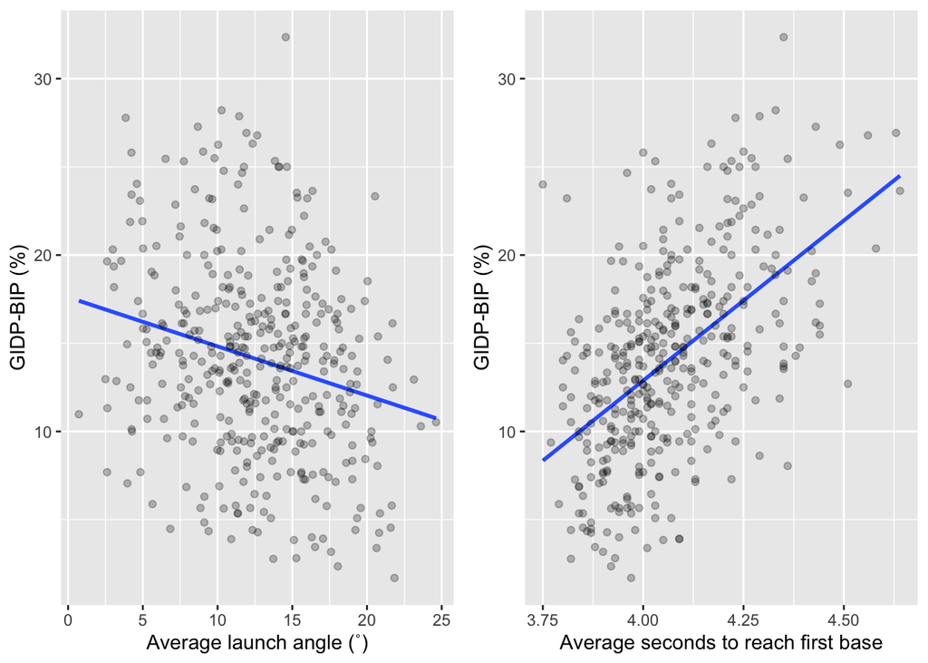

```r
launch_angle_leaderboard <- all_pitches %>%
  filter(
    description == "hit_into_play", !is.na(launch_angle)
  ) %>%
  summarize(
    launch_angle = mean(launch_angle),
    .by = c("player_name", "stand", "season")
  )

gidp_modelling <- reduce(
  list(gidp_bip_leaderboard, launch_angle_leaderboard, running_splits),
  inner_join,
  by = c("player_name", "stand", "season")
)

launch_angle_vs_gidp_bip <-
  ggplot(gidp_modelling, mapping = aes(x = launch_angle, y = `GIDP-BIP`)) +
  geom_smooth(method = lm, se = FALSE) +
  geom_point(alpha = 0.25) +
  xlab("Average launch angle (˚)") +
  ylab("GIDP-BIP (%)")

home_to_first_vs_gidp_bip <-
  ggplot(gidp_modelling, mapping = aes(x = home_to_first, y = `GIDP-BIP`)) +
  geom_smooth(method = lm, se = FALSE) +
  geom_point(alpha = 0.25) +
  xlab("Average seconds to reach first base") +
  ylab("GIDP-BIP (%)")

grid.arrange(launch_angle_vs_gidp_bip, home_to_first_vs_gidp_bip, nrow = 1)
```

```r
gidp_bip_correlations <- gidp_modelling %>%
  select(launch_angle, home_to_first, `GIDP-BIP`) %>%
  cor(method = "spearman")

gidp_bip_correlations %>%
  kbl(
    align = rep("c", ncol(gidp_bip_correlations)),
    digits = 3,
    caption = "Spearman correlation matrix"
  ) %>%
  kable_styling(
    full_width = FALSE,
    bootstrap_options = c("striped", "hover", "condensed", "responsive")
  )
```

Spearman correlation matrix

|  | launch_angle | home_to_first | GIDP-BIP |
| --- | --- | --- | --- |
| launch_angle | 1.000 | 0.129 | -0.214 |
| home_to_first | 0.129 | 1.000 | 0.529 |
| GIDP-BIP | -0.214 | 0.529 | 1.000 |

Judging from these plots and the corresponding Spearman correlations, it appears that both of these factors influence, but certainly don’t fully explain, inter-batter variance in GIDP-BIP. This may also explain in part why left-handed hitters, who have to travel a shorter distance from their batter’s box to first base, were over-represented in the “lowest GIDP-BIP” leaderboard shown above. It’s possible that the tendency of left-handed hitters to hit to the right side of the infield also impacts their collective GIDP-BIP, but we’ll save an exploration of spray angle for a later part of this series.

While batter speed sits outside the scope of this investigation of situational hitting, launch angle does not. It, together with launch speed (also called exit velocity) is known to be very much under the batter’s influence, and consequently it’s conceivable that batters could deliberately alter their average launch angle - and thus their likelihood of grounding into a double play - in specific situations.

To assess whether batters modulate their launch angle and/or launch speed to try and avoid double plays, we’ll first need a way of quantifying how likely a given ball put into play is to be a GIDP, based only on those two factors. I’ll call this metric “expected GIDP”, or xGIDP.

To calculate xGIDP, I’ll take a cue from how other expected statistics such as xBA are [calculated](https://technology.mlblogs.com/augmenting-statcast-expected-batting-average-with-sprint-speed-6be7f60770d2), and leverage a *k*-nearest neighbours regression model. I’ll train the model on every ball hit into play during a double play situation in the 2021 or 2022 regular seasons.

```r
knn_data <- all_pitches %>%
  filter(
    is_ball_in_play,
    on_1b & outs_when_up < 2,
    !is.na(launch_speed) & !is.na(launch_angle)
  ) %>%
  mutate(is_gidp = (events == "grounded_into_double_play"))
```

One day while I was working on this article, Vladimir Guerrero Jr. made a [heads-up play](https://www.mlb.com/video/yimi-garcia-in-play-out-s-to-will-benson) on a Will Benson pop-up to record what is (technically) a GIDP. Let’s check our data to confirm that it doesn’t contain any other pop-ups or fly balls that were recorded as GIDPs, using a 30˚ launch angle as a cutoff.

```r
filter(knn_data, is_gidp & launch_angle > 30) %>%
  select(key, is_gidp, game_date, player_name, launch_speed, launch_angle) %>%
  kable(
    align = rep("c", 6),
    caption = "GIDPs with suspiciously high launch angles"
  ) %>%
  kable_styling(
    bootstrap_options = c("striped", "hover", "condensed", "responsive")
  )
```

GIDPs with suspiciously high launch angles

| key | is_gidp | game_date | player_name | launch_speed | launch_angle |
| --- | --- | --- | --- | --- | --- |
| 56059 | TRUE | 2022-09-04 | Escobar, Eduardo | 72.7 | 37 |
| 71061 | TRUE | 2022-06-04 | Castro, Rodolfo | 60.2 | 71 |
| 286984 | TRUE | 2022-06-12 | Rojas, Josh | 23.0 | 48 |
| 293783 | TRUE | 2021-10-01 | Rodriguez, Eduardo | 29.6 | 65 |
| 478616 | TRUE | 2022-09-03 | García, Luis | 47.2 | 46 |
| 629102 | TRUE | 2021-07-07 | Soler, Jorge | 31.4 | 40 |
| 652624 | TRUE | 2021-07-25 | Sanó, Miguel | 31.3 | 47 |
| 691855 | TRUE | 2021-04-26 | Wainwright, Adam | 25.1 | 56 |
| 806040 | TRUE | 2021-09-12 | Canha, Mark | 42.9 | 62 |
| 1064876 | TRUE | 2021-04-25 | García, Avisaíl | 62.1 | 52 |
| 1071663 | TRUE | 2022-07-04 | Miranda, Jose | 34.8 | 33 |
| 1153477 | TRUE | 2021-05-21 | Bote, David | 43.5 | 31 |
| 1222223 | TRUE | 2022-05-29 | Kiner-Falefa, Isiah | 32.2 | 32 |

I’ll use the [video search](https://www.mlb.com/video) feature of the MLB website to track down and watch the replays of each of these double plays.

The results of that video review are as follows: 6 of the 13 “GIDPs” were actually pop-ups, and 4 of the 13 appeared on video to be completely ordinary ground balls, which suggests that the Statcast measurement of their launch angle was incorrect. Statcast errors aren’t [unheard of](https://tht.fangraphs.com/the-physics-of-statcast-errors/), unfortunately. I’ll use the “key” variable to exclude those 10 events from the dataset that the knn model will use, since they don’t represent standard, accurately measured GIDPs.

```r
knn_data <- knn_data %>%
  filter(
    !key %in% c(
      56059, 71061, 293783, 478616, 652624, 691855, 1064876, 1071663, 1153477,
      1222223
    )
  )
```

Now I can set up to train the *k*-nearest neighbours regression model. I’ll use a 80/20 training/test split. I’ll also need to scale the predictors (launch angle and launch speed) so that they’re weighted equally when calculating the distance between points.

```r
set.seed(714)

# caret assigns rownames, so the predictors should be in the form of a data
# frame instead of a tibble.
gidp_predictors <- knn_data %>%
  select(launch_speed, launch_angle) %>%
  as.data.frame()
gidp_responses <- as.integer(knn_data$is_gidp)

preprocessing <- preProcess(
  gidp_predictors,
  method = "range", rangeBounds = c(0, 1)
)
gidp_predictors <- predict(preprocessing, gidp_predictors)

train_indices <- createDataPartition(gidp_responses, p = 0.8, list = FALSE)
train_gidp_predictors <- gidp_predictors[train_indices, ]
train_gidp_responses <- gidp_responses[train_indices]
test_gidp_predictors <- gidp_predictors[-train_indices, ]
test_gidp_responses <- gidp_responses[-train_indices]
```

*k*-nearest neighbour models only have one hyperparameter, *k*. It controls the number of nearest neighbours whose responses will be averaged to predict the response of novel inputs. The general heuristic is that the optimal value of *k* is often near sqrt(n), where n is the number of points in the training dataset. I’ll use 10-fold cross-validation to calculate the root mean square error (RMSE) for different values of *k*, spanning from roughly 0.5 * sqrt(n) to 2 * sqrt(n). I’ll also store the results of the cross-validation locally to avoid having to repeat this step every time I run this analysis.

```r
knn_fit_control <- trainControl(method = "cv", number = 10)
knn_grid <- expand.grid(k = seq(from = 100, to = 400, by = 20))

xgidp_knn <- train(
  x = train_gidp_predictors, y = train_gidp_responses, method = "knn",
  trControl = knn_fit_control, tuneGrid = knn_grid
) %>%
  write_rds(xgidp_knn_rds)
```

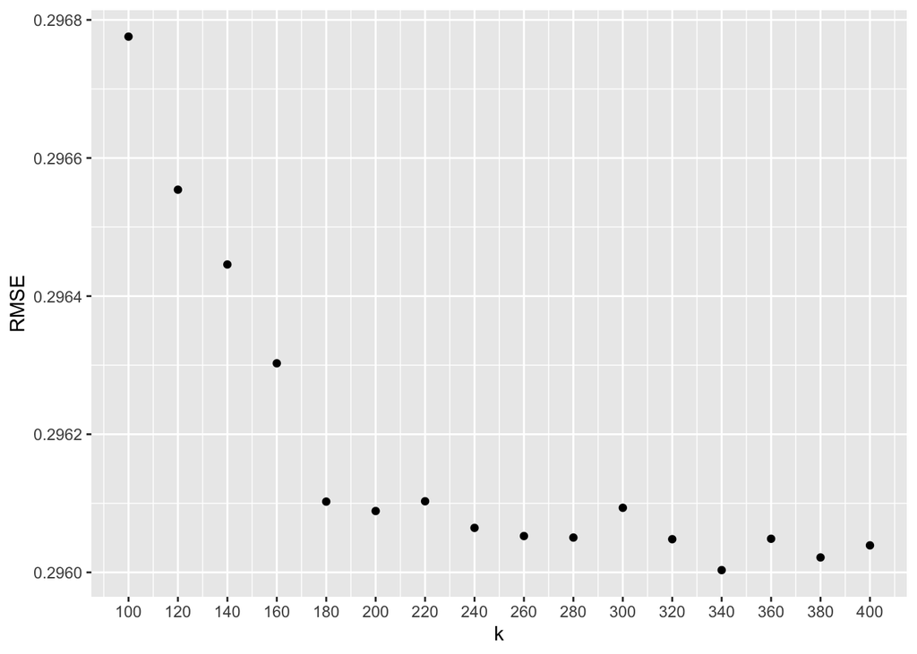

```r
cv_results <- read_rds(xgidp_knn_rds)$results

ggplot(cv_results, mapping = aes(x = k, y = RMSE)) +
  geom_point() +
  scale_x_continuous(breaks = seq(from = 100, to = 400, by = 20))
```

The RMSE declines continuously up to k = 200, where it reaches a local minimum of 0.296. Even though the global minimum RMSE is reached at k = 340, I’ll use k = 200 in the final model to try and prevent overfitting.

Let’s check how this model with k = 200 performs on our test dataset:

```r
xgidp_knn <- train(
  x = train_gidp_predictors, y = train_gidp_responses, method = "knn",
  trControl = trainControl(method = "none"),
  tuneGrid = expand.grid(k = 200)
)

test_gidp_predictions <- predict(xgidp_knn, newdata = test_gidp_predictors)
knn_test_results <-
  postResample(pred = test_gidp_predictions, obs = test_gidp_responses)
```

The RMSE is actually slightly lower on the test dataset (0.294) than it was on the training dataset, which is great, as it suggests that we didn’t overfit.

We can now use our finalized model to assign an xGIDP to any launch angle/speed combination.

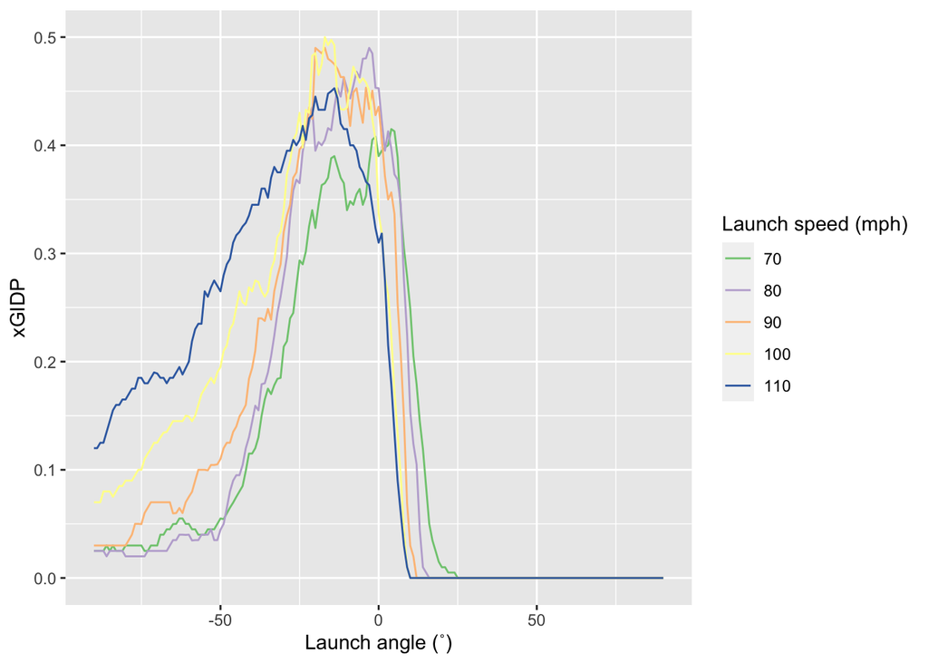

```r
mock_launch_speeds <- seq.int(from = 70, to = 110, by = 10)
mock_launch_angles <- seq.int(from = -90, to = 90, by = 1)
mock_xGIDP_data <- crossing(mock_launch_speeds, mock_launch_angles) %>%
  rename(launch_speed = mock_launch_speeds, launch_angle = mock_launch_angles)
scaled_mock_xGIDP_data <- predict(preprocessing, mock_xGIDP_data)

mock_xGIDP_data %>%
  mutate(xGIDP = predict(xgidp_knn, scaled_mock_xGIDP_data)) %>%
  ggplot(mapping = aes(x = launch_angle, y = xGIDP, color = as.factor(launch_speed))) +
  geom_line() +
  scale_color_brewer(type = "qual") +
  xlab("Launch angle (˚)") +
  labs(color = "Launch speed (mph)")
```

The results here generally look reasonable. The xGIDP is highest for balls hit at moderately low launch angles (-25 to 0˚). At launch angles below -25˚, launch speed correlates positively with xGIDP, because softly hit balls won’t reach infielders quickly enough. Conversely, launch speed is negatively correlated with xGIDP at positive launch angles (0 to 25˚), probably because hard hit balls are more likely to get past infielders for base hits. We also see that xGIDP declines to 0 as the launch angle increases further, with the decline happening more quickly for hard hit balls.

As a further sanity check, we can bin every ball put into play in a GIDP situation by xGIDP and then calculate the proportion of plays in each of those bins that actually resulted in a GIDP.

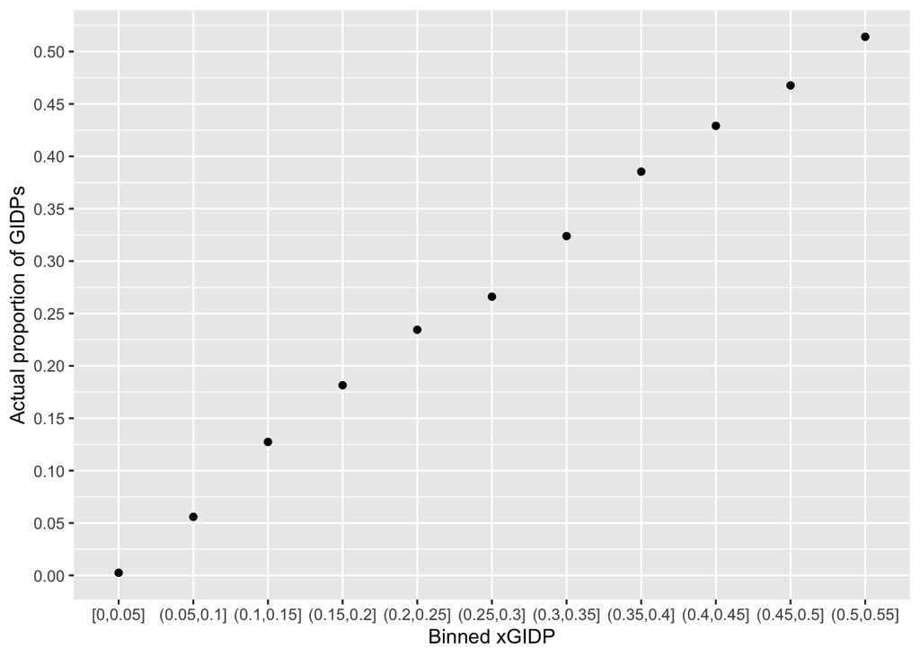

```r
knn_data <- knn_data %>%
  mutate(
    xGIDP = predict(xgidp_knn, gidp_predictors),
    xGIDP_bin = cut_width(xGIDP, width = 0.05, boundary = 0)
  )

knn_data %>%
  summarize(percentage_of_GIDP = mean(is_gidp), .by = xGIDP_bin) %>%
  ggplot() +
  geom_point(mapping = aes(x = xGIDP_bin, y = percentage_of_GIDP)) +
  xlab("Binned xGIDP") +
  ylab("Actual proportion of GIDPs") +
  scale_y_continuous(breaks = seq(from = 0, to = 0.55, by = 0.05))
```

The actual proportion of GIDPs for the plays in a given bin lies within the xGIDP bounds of the bin in all cases, which is great.

Using this model, we can now calculate the xGIDP for *every* ball put in play in 2021 and 2022, including those that weren’t hit in double play situations. We can then do a couple of interesting things, including ranking hitters by their overall season xGIDP. This will remove the effects of batter speed and situation (i.e. was there a runner on first when a ground ball was hit) and just tell us which batters hit the most double play balls.

```r
all_balls_in_play <- all_pitches %>%
  filter(
    description == "hit_into_play", !is.na(launch_angle),
    !is.na(launch_speed)
  )

all_xGIDP_predictors <- select(all_balls_in_play, launch_speed, launch_angle)
all_xGIDP_predictors <- predict(preprocessing, all_xGIDP_predictors)

all_balls_in_play <- all_balls_in_play %>%
  mutate(xGIDP = predict(xgidp_knn, all_xGIDP_predictors)) %>%
  write_csv(xgidp_for_balls_in_play_csv)

xGIDP_leaderboard <- all_balls_in_play %>%
  summarize(
    xGIDP = mean(xGIDP),
    balls_in_play = n(),
    .by = c("player_name", "season", "stand")
  ) %>%
  filter(balls_in_play >= 150)

min_max_xGIDP_leaderboard <- bind_rows(
  slice_max(xGIDP_leaderboard, order_by = xGIDP, n = 5),
  slice_min(xGIDP_leaderboard, order_by = xGIDP, n = 5)
)

min_max_xGIDP_leaderboard %>%
  kbl(
    col.names = c("Batter", "Season", "Bats", "xGIDP", "Balls in Play"),
    align = rep("c", ncol(min_max_xGIDP_leaderboard)), digits = 3
  ) %>%
  kable_styling(
    full_width = FALSE,
    bootstrap_options = c("striped", "hover", "condensed", "responsive")
  ) %>%
  pack_rows("Highest xGIDP", 1, 5) %>%
  pack_rows("Lowest xGIDP", 6, 10)
```

| Batter | Season | Bats | xGIDP | Balls in Play |
| --- | --- | --- | --- | --- |
| **Highest xGIDP** |  |  |  |  |
| Tapia, Raimel | 2021 | L | 0.225 | 420 |
| González, Erik | 2021 | R | 0.214 | 179 |
| Neuse, Sheldon | 2022 | R | 0.213 | 187 |
| Madrigal, Nick | 2021 | R | 0.205 | 184 |
| Madrigal, Nick | 2022 | R | 0.201 | 179 |
| **Lowest xGIDP** |  |  |  |  |
| Gorman, Nolan | 2022 | L | 0.077 | 180 |
| Gallo, Joey | 2022 | L | 0.079 | 188 |
| Trout, Mike | 2022 | R | 0.084 | 300 |
| Belt, Brandon | 2021 | L | 0.084 | 223 |
| Grossman, Robbie | 2021 | L | 0.085 | 276 |

And there we have it! At the top of the leaderboard sits Raimel Tapia, whose .225 xGIDP in 2021 nearly triples the lowest observed xGIDP: Nolan Gorman’s .077 mark in 2022. Tapia’s ground ball rate in 2021 was a bewildering [67.5%](https://www.baseball-reference.com/players/t/tapiara01.shtml#batting_advanced), while Gorman’s 2022 ground ball rate was just [27.2%](https://www.baseball-reference.com/players/g/gormano01.shtml#batting_advanced). It’s also worth noting that Nick Madrigal’s 2021 and 2022 seasons *both* make the top 5 by xGIDP.

Finally, to confirm that avoiding GIDPs is truly a repeatable skill for batters and that it extends beyond simply being a fast runner, let’s check how strongly correlated each player’s 2021 xGIDP was to their 2022 result.

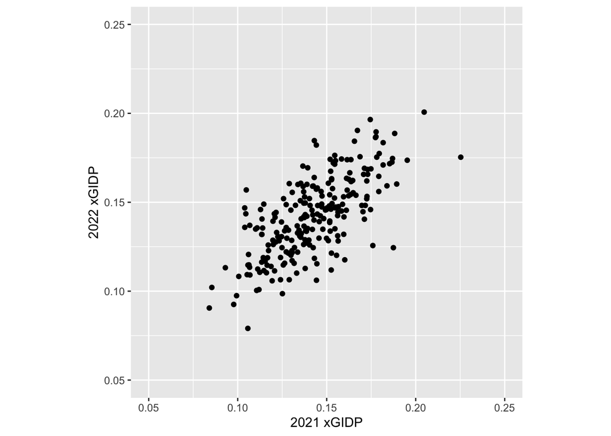

```r
xGIDP_by_season <- xGIDP_leaderboard %>%
  select(-balls_in_play) %>%
  pivot_wider(
    names_from = season, names_prefix = "xGIDP_", values_from = xGIDP
  ) %>%
  filter(if_all(starts_with("xGIDP"), ~ !is.na(.x)))

ggplot(xGIDP_by_season) +
  geom_point(mapping = aes(x = xGIDP_2021, y = xGIDP_2022)) +
  coord_equal() +
  xlim(c(0.05, 0.25)) +
  ylim(c(0.05, 0.25)) +
  xlab("2021 xGIDP") +
  ylab("2022 xGIDP")
```

Even by eye, it’s evident that there’s a very strong year-to-year correlation for batter xGIDP. The r<sup>2</sup> value here is 0.487, which suggests that just under half of the inter-batter variance in 2022 xGIDPs can be explained by each batter’s 2021 xGIDP.

### Summary

- Some batters hit into far more double plays than others.
- Part of this variation is due to differences in average launch angle, which is a characteristic that batters could theoretically alter by changing their hitting approach in double play situations.
- Launch angle and launch speed can be used to construct a *k*-nearest neighbours model that estimates the likelihood of a batted ball leading to a GIDP (xGIDP).
- A batter’s average xGIDP in one year is strongly correlated to their average xGIDP in the following year, suggesting that maintaining a low xGIDP is a true skill.

Next time I’ll examine whether xGIDP varies between double play situations and other situations, and if so, explore the causes of this variation.